# kriging puy de dome

Emmanuel Chevassus

23/04/2020

Librairies utilisées

```r
library(sp)
library(gstat)
library(xlsx)
library(sp)
library(automap)
library(dplyr)
```

```r
library(ggplot2)
library(scales)
library(magrittr)
```

chargement des données experimentales dans le fichier xlsx, x est la longitude, y la latitude, et z la concentration en ozone(ppb)

```r
datdon=read.xlsx("/Users/Emmanuel/Desktop/ptut/kriging/test.xlsx", sheetIndex=1, header=TRUE, colClasses=NA)
mesurespdd<-datdon
```

Création de la grille sur laquelle les prédictions vont être representées

```r
coordinates(mesurespdd) <- ~ x + y
mesurespdd <-mesurespdd[-zerodist(mesurespdd)[,1],] #Zerodist permet de supprimer les coordonées qui se chevauchent.

class(mesurespdd)
```

```
## [1] "SpatialPointsDataFrame"
## attr(,"package")
## [1] "sp"
```

```r
str(mesurespdd)
```

```
## Formal class 'SpatialPointsDataFrame' [package "sp"] with 5 slots
##   ..@ data       :'data.frame':  214 obs. of  1 variable:
##   .. ..$ z: num [1:214] 44.6 42.7 43.5 45.2 43.3 42.2 43.5 44.1 45.2 45.2 ...
##   ..@ coords.nrs : int [1:2] 2 1
##   ..@ coords     : num [1:214, 1:2] 259 259 259 259 259 ...
##   .. ..- attr(*, "dimnames")=List of 2
##   .. .. ..$ : chr [1:214] "1" "2" "3" "4" ...
##   .. .. ..$ : chr [1:2] "x" "y"
##   ..@ bbox       : num [1:2, 1:2] 257 4546 259 4547
##   .. ..- attr(*, "dimnames")=List of 2
##   .. .. ..$ : chr [1:2] "x" "y"
##   .. .. ..$ : chr [1:2] "min" "max"
##   ..@ proj4string:Formal class 'CRS' [package "sp"] with 1 slot
##   .. .. ..@ projargs: chr NA
```

```r
bbox(mesurespdd)
```

```
##         min       max
## x  257.3861  259.2323
## y 4545.9633 4546.5047
```

```r
coordinates(mesurespdd) %>% glimpse
```

```
##  num [1:214, 1:2] 259 259 259 259 259 ...
##  - attr(*, "dimnames")=List of 2
##   ..$ : chr [1:214] "1" "2" "3" "4" ...
##   ..$ : chr [1:2] "x" "y"
```

```r
proj4string(mesurespdd)
```

```
## [1] NA
```

```r
identical( bbox(mesurespdd), mesurespdd@bbox )
```

```
## [1] TRUE
```

```r
identical( coordinates(mesurespdd), mesurespdd@coords )
```

```
## [1] TRUE
```

```r
mesurespdd@data %>% glimpse
```

```
## Observations: 214
## Variables: 1
## $ z <dbl> 44.6, 42.7, 43.5, 45.2, 43.3, 42.2, 43.5, 44.1, 45.2, 45.2, 44.0,...
```

```r
mesurespdd %>% as.data.frame %>% glimpse
```

```
## Observations: 214
## Variables: 3
## $ y <dbl> 4546.367, 4546.365, 4546.363, 4546.364, 4546.361, 4546.364, 4546....
## $ x <dbl> 259.2292, 259.2273, 259.2279, 259.2280, 259.2296, 259.2285, 259.2...
## $ z <dbl> 44.6, 42.7, 43.5, 45.2, 43.3, 42.2, 43.5, 44.1, 45.2, 45.2, 44.0,...
```

```r
# Convert to SpatialPointsDataFrame
#coordinates(mesurespdd) <- ~x+y
proj4string(mesurespdd) <- CRS("+init=epsg:2154") #projection en coordonées Lambertiennes


x=seq(from = min(mesurespdd$x), to = max(mesurespdd$x), by = 0.005) #by: resolution arbitraire que nous choisissons
y=seq(from = min(mesurespdd$y), to = max(mesurespdd$y), by = 0.005)

pts = expand.grid(x =x, y=y)
coordinates(pts) <- ~x+y
proj4string(pts) <- CRS("+init=epsg:2154")
mesurespdd.grid = SpatialPixels(SpatialPoints(pts))
proj4string(mesurespdd.grid) <- CRS("+init=epsg:2154")

summary(mesurespdd.grid)
```

```
## Object of class SpatialPixels
## Coordinates:
##         min       max
## x  257.3836  259.2336
## y 4545.9608 4546.5058
## Is projected: TRUE
## proj4string :
## [+init=epsg:2154 +proj=lcc +lat_1=49 +lat_2=44 +lat_0=46.5 +lon_0=3
## +x_0=700000 +y_0=6600000 +ellps=GRS80 +towgs84=0,0,0,0,0,0,0 +units=m
## +no_defs]
## Number of points: 40330
## Grid attributes:
##   cellcentre.offset cellsize cells.dim
## x          257.3861    0.005       370
## y         4545.9633    0.005       109
```

```r
class(mesurespdd.grid)
```

```
## [1] "SpatialPixels"
## attr(,"package")
## [1] "sp"
```

```r
gridded(mesurespdd.grid) <- TRUE

mesurespdd.grid <- as(mesurespdd.grid, "SpatialPixels")
```

Voici les plots de nos données brutes, et la grille de points sur laquelle nous allons travailler

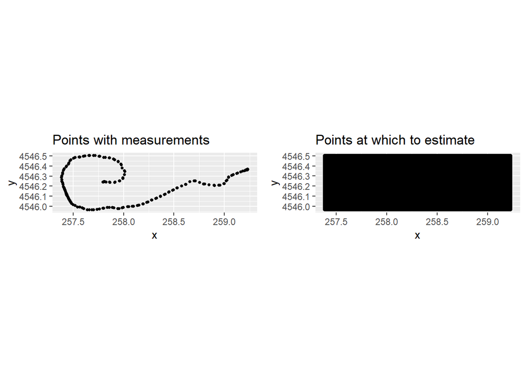

```r
plot1 <- mesurespdd %>% as.data.frame %>%
  ggplot(aes(x, y)) + geom_point(size=1) + coord_equal() +
  ggtitle("Points with measurements")

# this is clearly gridded over the region of interest
plot2 <- mesurespdd.grid %>% as.data.frame %>%
  ggplot(aes(x, y)) + geom_point(size=1) + coord_equal() +
  ggtitle("Points at which to estimate")

library(gridExtra)
grid.arrange(plot1, plot2, ncol = 2)
```

Nous voulons ensuite obtenir les variogrames(on paramètre le kriging)

```r
library(e1071)
skewness(datdon$z)
```

```
## [1] -0.7324065
```

on n’adopte donc pas de modèle logarithmique pour nos concentrations d’ozone.

Il faut préciser ici psill, range, nugget et model

range-Portée pratique = distance maximale d’auto-corrélation (lorsque la covariance devient constante).

sill-Valeur de la covariance atteinte par le semiovariogram lorsqu’il le range est atteint

nugget-Effet pépite = Variations de la covariance à très petite échelle (lag proche de 0).attribuable aux erreurs de mesures sur le terrain

psill=sill-nugget

model=Sph,Mat,Exp…à voir plus en détails

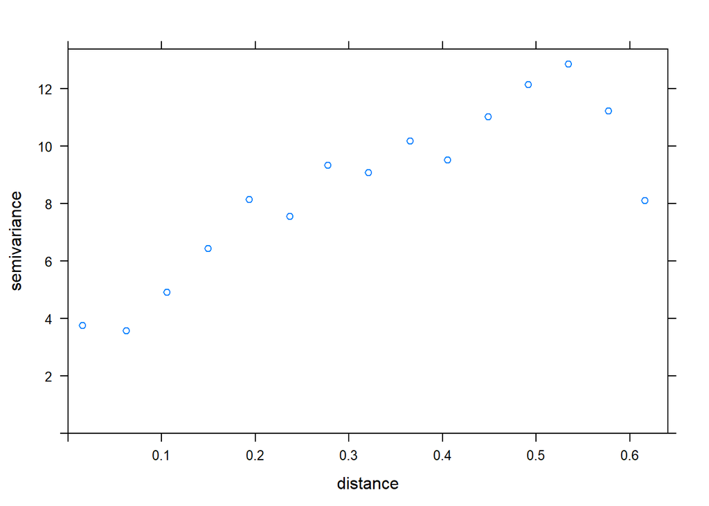

```r
 # calculates sample variogram values
lzn.vgm <- variogram(z~1, mesurespdd)
plot(lzn.vgm)
```

```r
sph.model <- vgm(psill=12, model="Sph", range=1, nugget=10)
lzn.fit <- fit.variogram(object = lzn.vgm, model = sph.model)
lzn.fit
```

```
##   model    psill     range
## 1   Nug 3.474137 0.0000000
## 2   Sph 8.599901 0.7438931
```

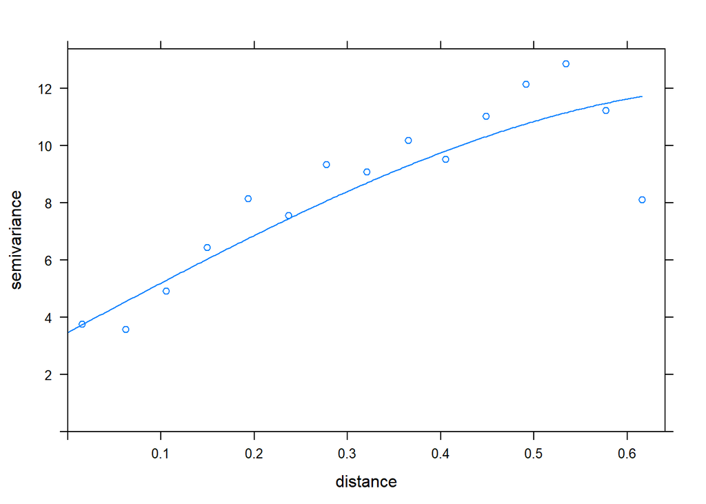

```r
plot(lzn.vgm, lzn.fit) # plot the sample values, along with the fit model
```

La valeur du range est de 0.7438931, la valeur du psill est 8.599901

```r
lzn.kriged <- krige(z ~ 1, mesurespdd, mesurespdd.grid, model=lzn.fit)
```

```
## [using ordinary kriging]
```

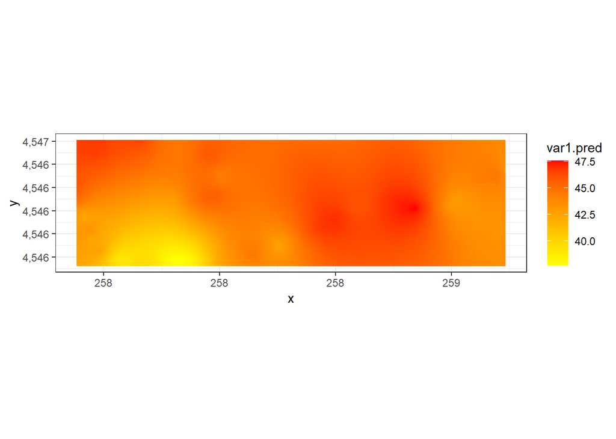

```r
lzn.kriged %>% as.data.frame %>%
  ggplot(aes(x=x, y=y)) + geom_tile(aes(fill=var1.pred)) + coord_equal() +
  scale_fill_gradient(low = "yellow", high="red") +
  scale_x_continuous(labels=comma) + scale_y_continuous(labels=comma) +
  theme_bw()
```

Notre variograme étant un peu grossier, ce premier kriging n’est pas encore très convaincant..

Heureusement,il existe une fonction autokrige estimant les paramètres du variogram automatiquement. Nous pouvons aussi utiliser les modèles “inverse weight distance”

```r
ozonekrig <- autoKrige(z~1, mesurespdd, mesurespdd.grid)
```

```
## [using ordinary kriging]
```

```r
PbIDW1 <- idw(formula=z~1,locations=mesurespdd,newdata=mesurespdd.grid,idp=1)
```

```
## [inverse distance weighted interpolation]
```

```r
PbIDW2 <- idw(formula=z~1,locations=mesurespdd,newdata=mesurespdd.grid,idp=2)
```

```
## [inverse distance weighted interpolation]
```

```r
PbIDW3 <- idw(formula=z~1,locations=mesurespdd,newdata=mesurespdd.grid,idp=3)
```

```
## [inverse distance weighted interpolation]
```

```r
PbIDW1modified <- idw(formula=z~1,locations=mesurespdd,newdata=mesurespdd.grid,'modified',idp=1)
```

```
## [inverse distance weighted interpolation]
```

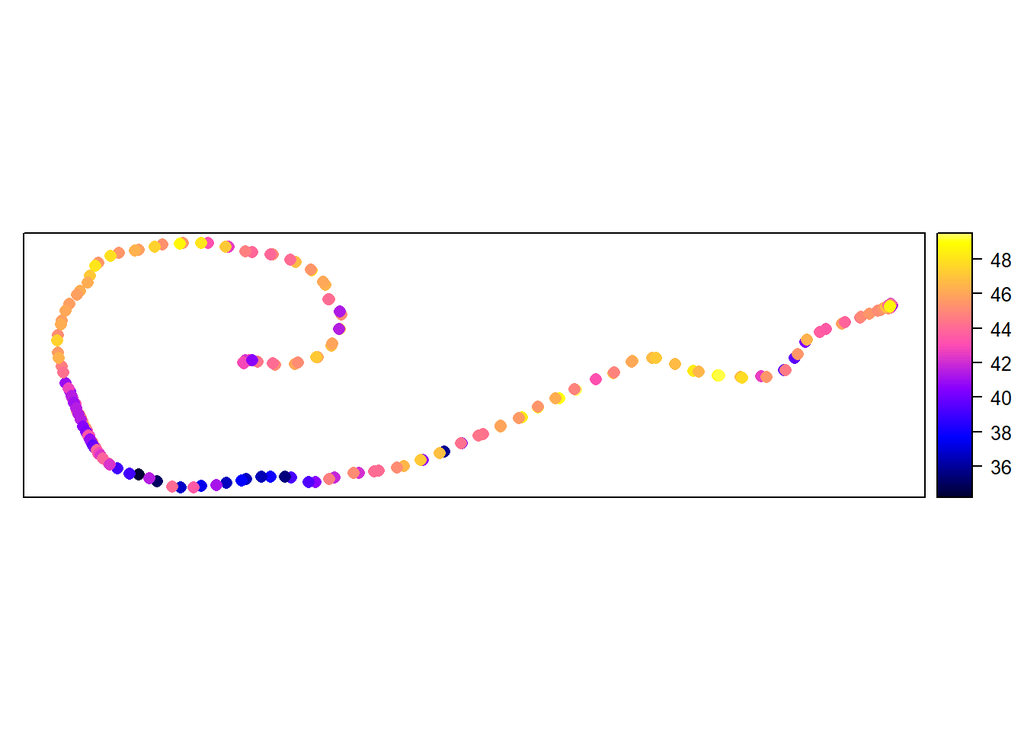

```r
spplot(mesurespdd,"z",colorkey=TRUE)
```

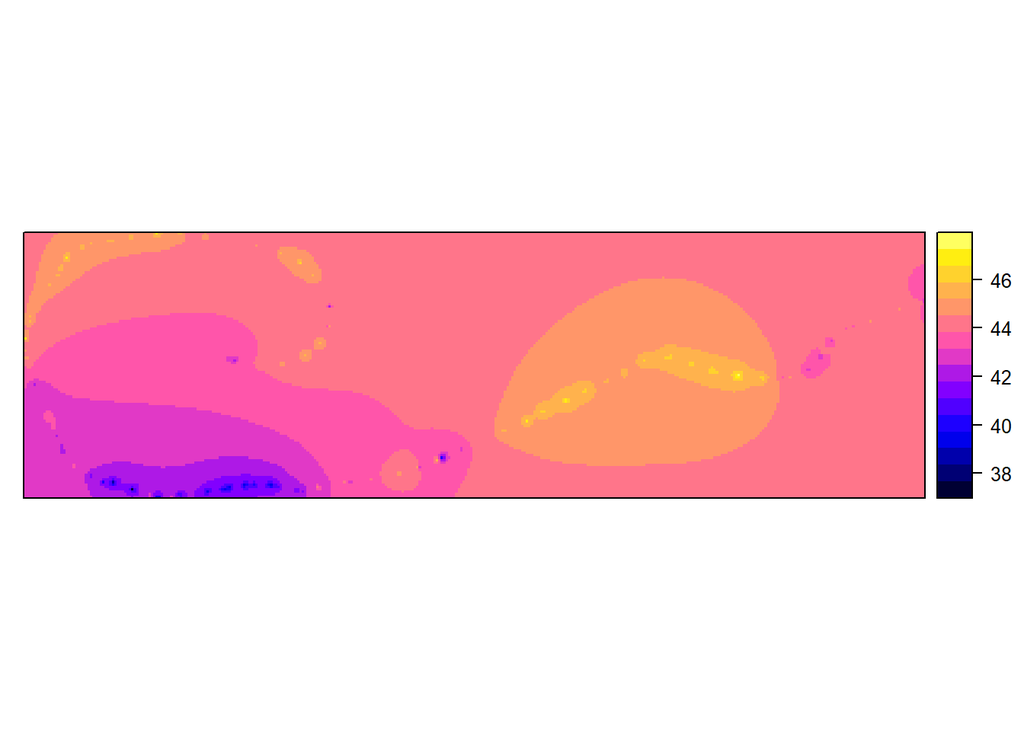

```r
spplot(PbIDW1,"var1.pred")
```

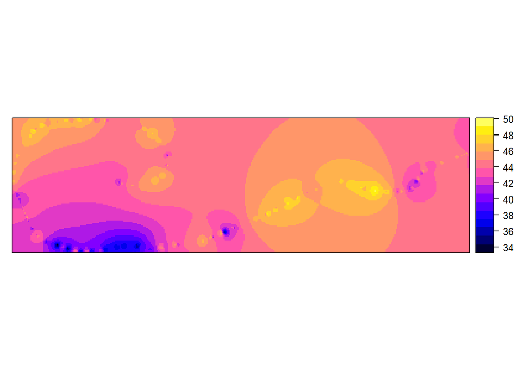

```r
spplot(PbIDW2,"var1.pred") #(Power = 2)
```

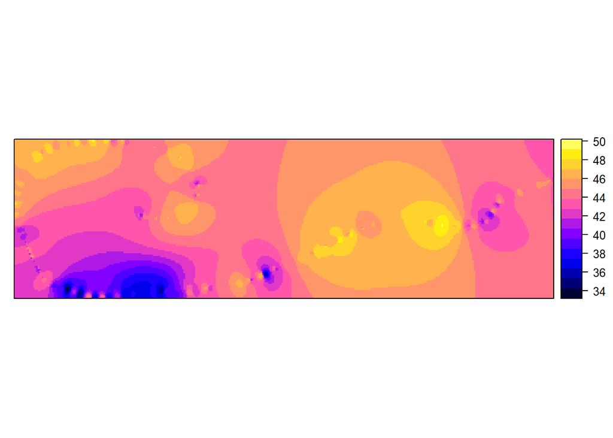

```r
spplot(PbIDW3,"var1.pred") #(Power = 3)
```

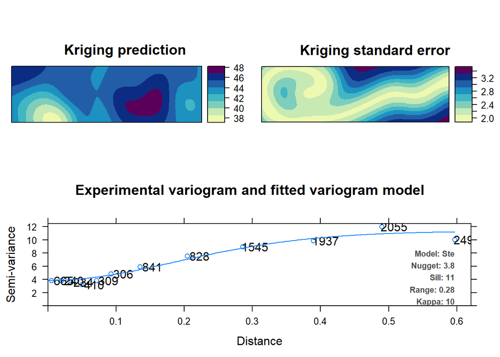

```r
plot(ozonekrig)
```

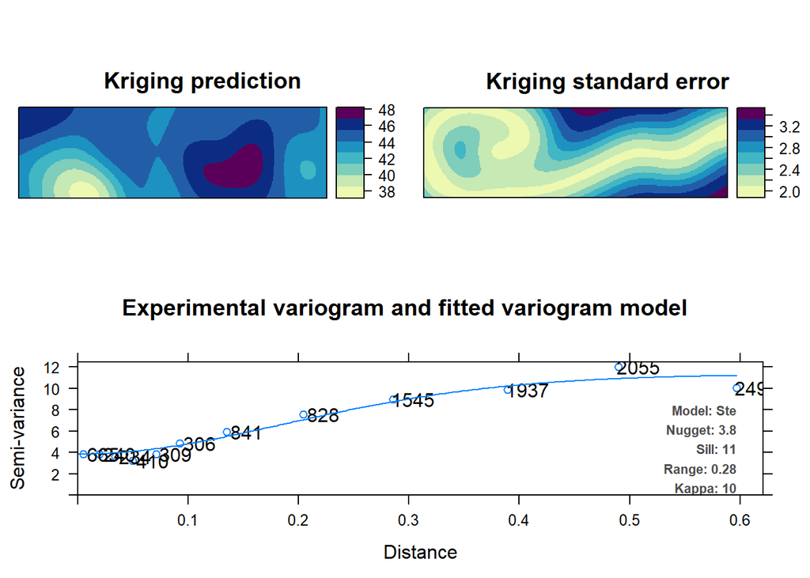

```r
plot(ozonekrig)
```

Le variogram montre les half squared differences entre les valeurs échantillonées (semivariance) et les paires de points. On s’attend à des petites semivariances pour les petites distances, et à une semivariance stable pour les plus longues distances On peut voir sur l’image en pièce-jointe que l’erreur du modèle autokrige est minime au niveau des coordonnées où les mesures ont été faites…